# Successful Companies vs Closed and Acquired: Data Analysis and Logistic regression model

Emilio Conde

2023-05-13

## Preamble:

#### This report presents an in-depth analysis of venture capital investments in Latin American startups, with the goal of identifying key characteristics that distinguish successful companies from those that fail.

#### The analysis is carried out in two stages: the first stage involves an exploratory data study of various Latin American startups across numerous metrics, while the second stage focuses on the development of a Logistic Regression model designed to predict the probability of a company’s success or failure.

> For the purpose of this analysis, we define success in the following way:  
> Successful companies are those that have secured at least one funding round exceeding 20 million dollars.  
> In contrast, unsuccessful companies are identified as those that have either shut down or have been acquired as a means of survival.

```r
# Libraries to use. We load them quietly
packages <- c("tidyverse", "googlesheets4", "glmnet", "caret", "ggthemes", "ggpubr", "stargazer",
              "psych","summarytools","kableExtra","scales","reshape2","car", "forcats", "caTools",
              "tidymodels","pROC", "ModelMetrics","oddsratio","epiDisplay","gridExtra")

invisible(lapply(packages, function(x) {
  suppressPackageStartupMessages(library(x, character.only = TRUE, quietly = TRUE))}))
```

#### The data for this analysis is sourced from the Pitchbook platform. Now, let’s begin by processing the raw dataset.

```r
raw_data_vc  <- sheet_data_invest %>%
  #Rename Variables
  rename(company= "Company",
         vertical= "Vertical General",
         status = "Status",
         hq = "HQ Company",
         deal_type = "Deal Type",
         team_composition = "Composición del equipo",
         founding_year ="Founding year (company)",
         funding_year = "Funding Year",
         funding_usd = "USD",
         employees = "Employees",
         total_raised= "Total Raised",
         funding_date = "Funding Date",
         n_investors = "Number of investors",
         clasf_unicorn= `New clasf unicorn`,
         exit_date = `Exit year`,
         team = `Composición del equipo`,
         hq_inv = `Headquarters of Lead Investor`) %>%
  # Group by company name
  group_by(company) %>%
  # Mutate different variables. Here I'm correcting some data capture errors.
  mutate(funding_date = as.Date(funding_date, format = "%Y-%m-%d"),
         founding_year =as.Date(paste(founding_year, "-01-01", sep = ""), format = "%Y-%m-%d"),
         exit_date =as.Date(paste(exit_date, "-01-01", sep = ""), format = "%Y-%m-%d"),
         end_date = as.Date(ifelse(status == "Closed", as.character(max(funding_date)),
                                   ifelse(status == "Acquired", as.character(exit_date), NA)), format = "%Y-%m-%d"),
         vertical = ifelse(vertical %in% c("Insurtech", "InsurTech"), "Insurtech", vertical),
         deal_type = ifelse(deal_type %in% c("Line of Credit", "Line of credit"), "Line of credit", deal_type),
         team = factor(ifelse(team %in% c("Equipo femenino", "Equipo Femenino"), "Equipo femenino",
                              ifelse(team %in% c("Equipo Mixto","Equipo mixto"),"Equipo mixto",team)),
                       levels = c("Equipo femenino","Equipo masculino","Equipo mixto",
                                  "Un solo hombre","Una sola mujer")),
         status = factor(ifelse(status %in% c("acquired", "Acquired"), "Acquired", status),
                         levels = c("Acquired","Closed","Operating")),
         clasf_unicorn = factor(ifelse(clasf_unicorn %in% c("Was acquired","Was Acquired"), "Was Acquired", clasf_unicorn),
                                levels = c("IPO","Rest of Companies","Soonicorn","Unicorn","Was Acquired")),
         # Calculate new variables based on existing ones. For example, get median funding by company
         median_funding = median(funding_usd, na.rm= T),
         total_investors = sum(n_investors),
         funding_rounds = n(),
         foreign_funding_all = if_else(hq_inv== hq,"No","Yes"),
         foreign_funding_all = factor(foreign_funding_all,levels = c("No","Yes")),
         foreign_funding = ifelse(
           hq != hq_inv &
             !(hq_inv %in% c("Argentina", "Brazil", "Chile",
                             "Colombia", "Ecuador", "Mexico",
                             "Peru", "Venezuela")),
           "Yes",
           "No"),
         same_country_funding = ifelse(hq==hq_inv,"Yes","No"),
         regional_funding = ifelse(hq %in% c("Argentina", "Brazil", "Chile",
                                             "Colombia", "Ecuador", "Mexico",
                                             "Peru", "Venezuela") &
                                     hq_inv %in% c("Argentina", "Brazil",
                                                   "Chile", "Colombia", "Ecuador",
                                                   "Mexico", "Peru", "Venezuela"), "Yes", "No"),
         # Here I'm manually correcting some data capture errors
         first_funding_round = case_when(
           company == "Brex" ~ as.Date("2019-04-16", format = "%Y-%m-%d"),
           company == "Hackmetrix" ~ as.Date("2020-07-01", format = "%Y-%m-%d"),
           company == "Hash (Financial Software)" ~ as.Date("2017-01-05", format = "%Y-%m-%d"),
           company == "Inventa (B2B Marketplace)" ~ as.Date("2021-08-17", format = "%Y-%m-%d"),
           company == "Kavak" ~ as.Date("2016-08-01", format = "%Y-%m-%d"),
           company == "Nexu" ~ as.Date("2014-01-01", format = "%Y-%m-%d"),
           company == "Solfacil" ~ as.Date("2018-01-01", format = "%Y-%m-%d"),
           TRUE ~ min(funding_date)),
         last_funding_round = case_when(
           company == "Brex" ~ as.Date("2019-12-11", format = "%Y-%m-%d"),
           company == "Hackmetrix" ~ as.Date("2021-11-28", format = "%Y-%m-%d"),
           company == "Hash (Financial Software)" ~ as.Date("2021-10-20", format = "%Y-%m-%d"),
           company == "Inventa (B2B Marketplace)" ~ as.Date("2022-01-23", format = "%Y-%m-%d"),
           company == "Kavak" ~ as.Date("2022-09-20", format = "%Y-%m-%d"),
           company == "Nexu" ~ as.Date("2022-01-26", format = "%Y-%m-%d"),
           company == "Solfacil" ~ as.Date("2022-09-22", format = "%Y-%m-%d"),
           TRUE ~ max(funding_date)),
         months_to_first_round = as.numeric(round(difftime(first_funding_round,founding_year, units = "days"))/30, digits =1),
         months_between_first_and_last_round = as.numeric(round(difftime(last_funding_round,
                                                                         first_funding_round, units = "days"))/30, digits=1),
         months_between_rounds = c(NA, diff(as.numeric(difftime(funding_date, lag(funding_date), units = "days"))/30)),
         team = case_when(
           team == "Equipo femenino" ~ "Co-Founder Team",
           team == "Equipo masculino" ~ "Co-Founder Team",
           team == "Equipo mixto" ~ "Co-Founder Team",
           team == "Un solo hombre" ~ "Solo Founder",
           team == "Una sola mujer" ~ "Solo Founder",
           TRUE  ~ team),
         team = factor(team,levels = c("Co-Founder Team","Solo Founder")),
         avg_months_between_rounds = mean(months_between_rounds, na.rm = TRUE)) %>%
  # Filter out NAs and absurd variables, such as a company having 0 investors or negative total raised
  filter(complete.cases(funding_usd,total_raised, n_investors, founding_year, employees, funding_date),
         !grepl("Undisclosed - VC", deal_type),
         n_investors >0,
         total_raised >0,
         as.numeric(format(founding_year, "%Y")) >= 2013) %>%
  # Company classification starts from this point.
  # Companies classified as Unicorns or Soonicorns are considered to be those who have gotten a +20M USD Funding round
  # I'm only considering companies that closed or were acquired from 2018 to beyond.
  filter(clasf_unicorn%in% c("Unicorn","Soonicorn")|status%in% c("Closed","Acquired")
         &  as.numeric(format(end_date, "%Y")) >= 2018) %>%
  # Successful companies will be those with a Unicorn or Soonicorn status
  # Not Successful companies will be those that were closed or acquired
  mutate(success = ifelse(clasf_unicorn %in% c("Unicorn", "Soonicorn"), "Successful",
                          ifelse(status%in% c("Closed","Acquired"),"Not successful",NA)),
         success = ifelse(company %in% c("Auth0", "Checkars", "Cornershop","Daki"), "Successful", success),
         success = factor(success,levels = c("Successful","Not successful"))) %>%
  dplyr::select(company,vertical, hq, hq_inv,success, founding_year,end_date,foreign_funding_all, same_country_funding,
         median_funding, funding_usd,
         regional_funding, employees, team, months_to_first_round,
         months_between_first_and_last_round, avg_months_between_rounds,
         total_raised, funding_rounds, n_investors) %>%
  distinct(company, .keep_all = T)
```

#### This data was obtained via a LinkedIn Scrapper, let’s clean and join both the investments data with the founder data

```r
raw_data_scraper <- sheet_data_scraper %>%
  # Rename Variables
  rename(company = `Nombre de la compañía del mapeo`,
         exp_years = "Años de Experiencia",
         entrep_exp_years = "Años de experiencia como emprendedor",
         age = "Edad Actual",
         entrep_age= "Edad de emprendimiento",
         n_entrep_founded = "Numero de emprendimientos Fundados",
         hundred_employees = "Worked on a +100 Company",
         status = "Status Unicorn (1=unicorn, 3=soonicorn, 0=other companies)",
         foreign_exp = "Foreign exp",
         cofounders = "No. de Cofounders",
         founders = "# founders",
         employments_before_entrep= "Empleos previos a emprender",
         business = Business,
         entrep = Entrepreneurship,
         finance = Financial,
         marketing = Marketing,
         maths_eng = `Maths & Engineering`,
         pmanag= `Project Management`,
         research = Research,
         sales = Sales,
         soft = `Soft Skills`,
         consulting_exp = Consulting_exp,
         founder_exp = Founder_exp,
         clevel_exp= cLevel_exp,
         field_of_study = `Undergraduate field of study`,
         exp_years_categ = `Categorización Años de experiencia`,
         foreign_exp = "Foreign exp") %>%
  group_by(company) %>%
  dplyr::select(company,exp_years, exp_years_categ,cofounders,
         entrep_exp_years,employments_before_entrep,
         age,entrep_age,n_entrep_founded,hundred_employees,
         business,entrep,finance,marketing,maths_eng,pmanag,
         research,sales,soft,manager_exp,clevel_exp,engineering_exp,
         sales_exp,finance_exp,human_capital_exp,consulting_exp,founder_exp, field_of_study, foreign_exp) %>%
  # Mutate and create new variables by company
  mutate(cofounders = dplyr::recode(cofounders,
                             "2 Cofounders" = 2,
                             "3 Cofounders" = 3,
                             "4 Cofounders" = 4,
                             "5 o más Cofounders" = 5,
                             "Single founder" = 1),
         exp_years = sum(exp_years),
         entrep_exp_years=sum(entrep_exp_years),
         employments_before_entrep = sum(employments_before_entrep),
         age = median(age),
         entrep_age = median(entrep_age),
         across(n_entrep_founded:founder_exp,sum)) %>%
  filter(exp_years >= 0) %>%
  # Keep a unique observation for each company
  distinct(company, .keep_all = T)

# Join founder data with the investments their company received.
joined_data_scraper <- left_join(raw_data_vc,raw_data_scraper, by = "company") %>%
  mutate(cofounders = as.character(cofounders),
         cofounders = if_else(cofounders %in% c("4", "5"), "4+", cofounders)) %>%
  filter(!is.na(cofounders)) %>%
  group_by(cofounders) %>%
  mutate(team = case_when(
    cofounders == 1 ~ "Solo Founder",
    TRUE ~ "Co-Founder Team"))
```

For confidentiality reasons, I can’t provide the complete data frame. However, I’m able to share a more condensed, high-level view of the data:

Figure 1. Glimpse on Companies Data

| company | hq | total_raised | months_between_first_and_last_round | team |
| --- | --- | --- | --- | --- |
| Movidesk | Brazil | 45000000 | 20.53333 | Co-Founder Team |
| Stattus4 | Brazil | 48760000 | 65.23333 | Solo Founder |
| C6 Bank | Brazil | 2250488310 | 10.90000 | Co-Founder Team |
| Flapper | Brazil | 42086356 | 74.10000 | Co-Founder Team |
| Chiper | Colombia | 76700000 | 23.93333 | Co-Founder Team |

# Part 1: Understanding Key Differences

First, let’s take a look at the median values. Given the non-normal distribution of the data, I’m focusing on examining the median values for each pertinent variable in the processed dataset.

Figure 2. Summary Table: Median Values

| Variable | Successful | Not successful |
| --- | --- | --- |
| Months to first round | 17 | 19 |
| Months between first and last round | 29 | 14 |
| Funding rounds | 4 | 2 |
| Employees | 174 | 11 |
| Investors | 3 | 1 |
| Founding Year | 2017 | 2016 |
| End Year | NA | 2020 |

The table reveals some intriguing findings:  
- Successful companies typically **secure their initial funding round two months ahead of unsuccessful ones.**  
- Successful companies **usually have two additional funding rounds compared to unsuccessful ones.**  
- Unsuccessful companies **often struggle to expand their workforce beyond 50 employees.**  
- The highest number of **closures among unsuccessful companies occurred in 2020**, likely **influenced by the pandemic and issues accessing funding.**

### Now let’s plot some key differences

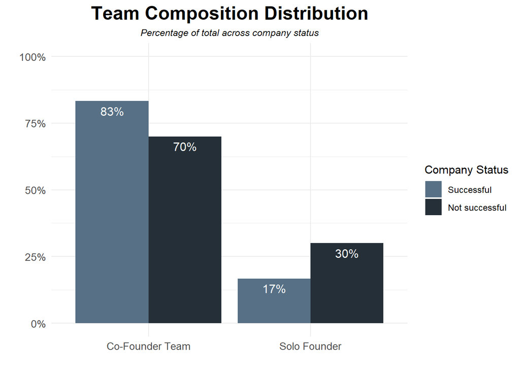

Figure 3. Team Composition Distribution

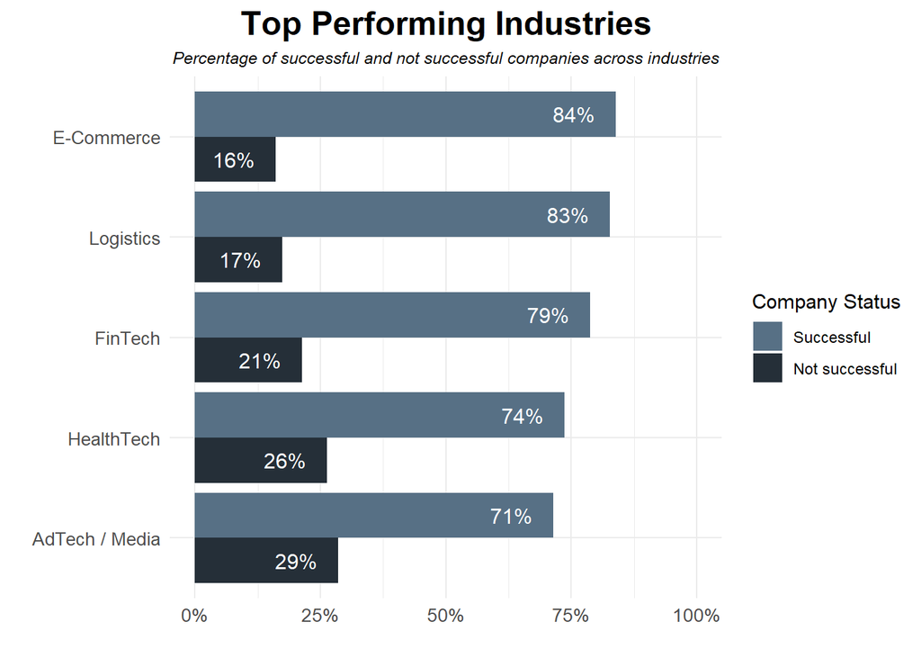

Figure 4: Top Performing Industries

- E-commerce stands out as the most successful industry, with **84% of companies in this sector achieving success.**  
- Conversely, the AdTech/Media industry exhibits the highest failure rate, as **29% of companies within this sector have either shut down or been acquired.**

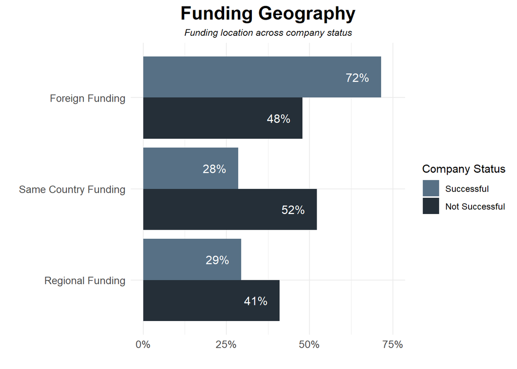

Figure 5. Funding Locations

Another noteworthy observation pertains to the geographical origin of funding that entrepreneurs secure.  
- Successful companies have **72% rate of getting a foreign funding round.**  
- On the other hand, unsuccessful companies get much more funding from local funds, with **52% receiving funds within their same country** versus **28% for successful companies**

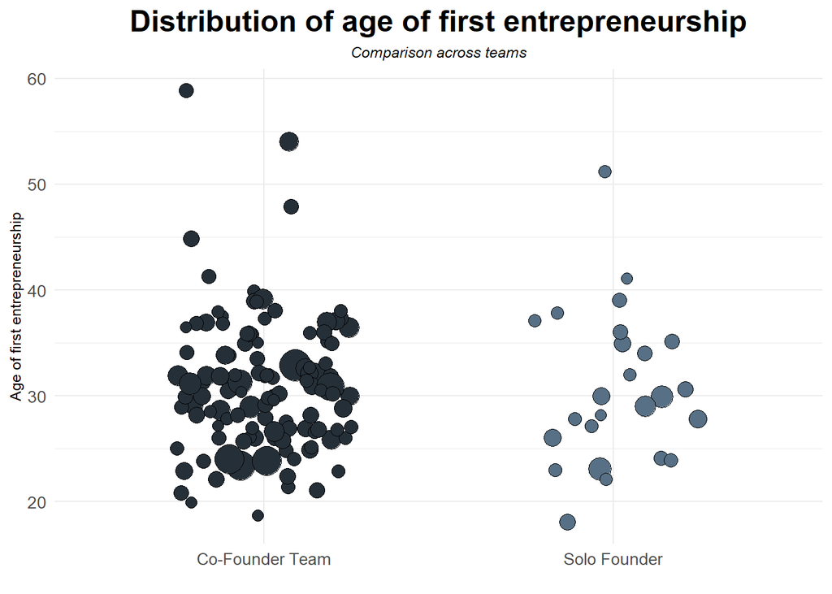

Figure 6. Distribution of first entrepreneurship

- The graph displays the age distribution of their first venture for both teams.  
- Solo founders tend to launch their first venture two years earlier than co-founder teams.  
- The bubble size represents the number of employees for each age.  
-It’s observed that for both teams, the longer their venture has been operating, the more employees they manage.

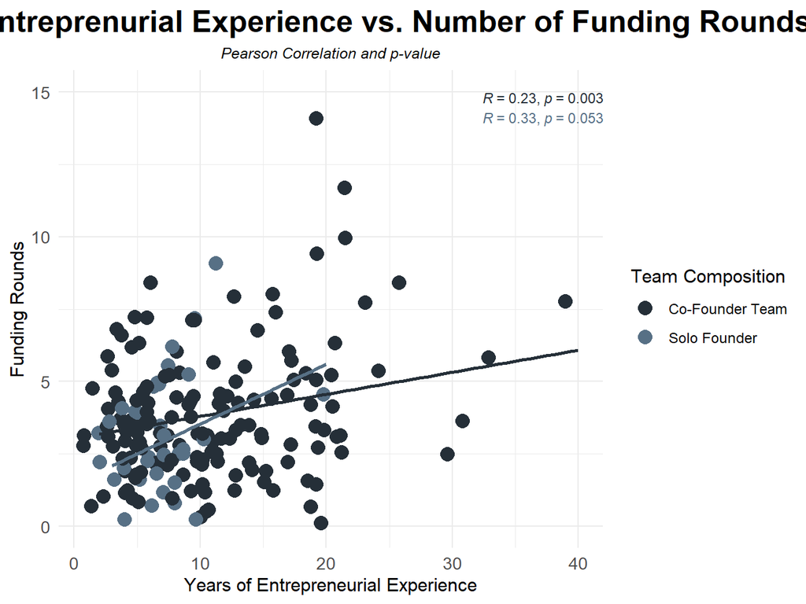

Figure 7. Correlation graph

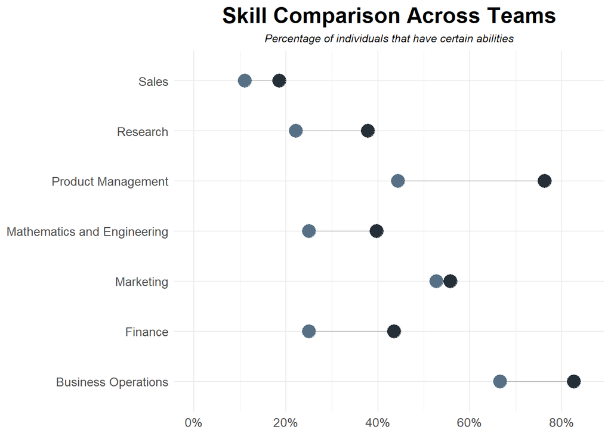

Figure 8. Skills Comparison

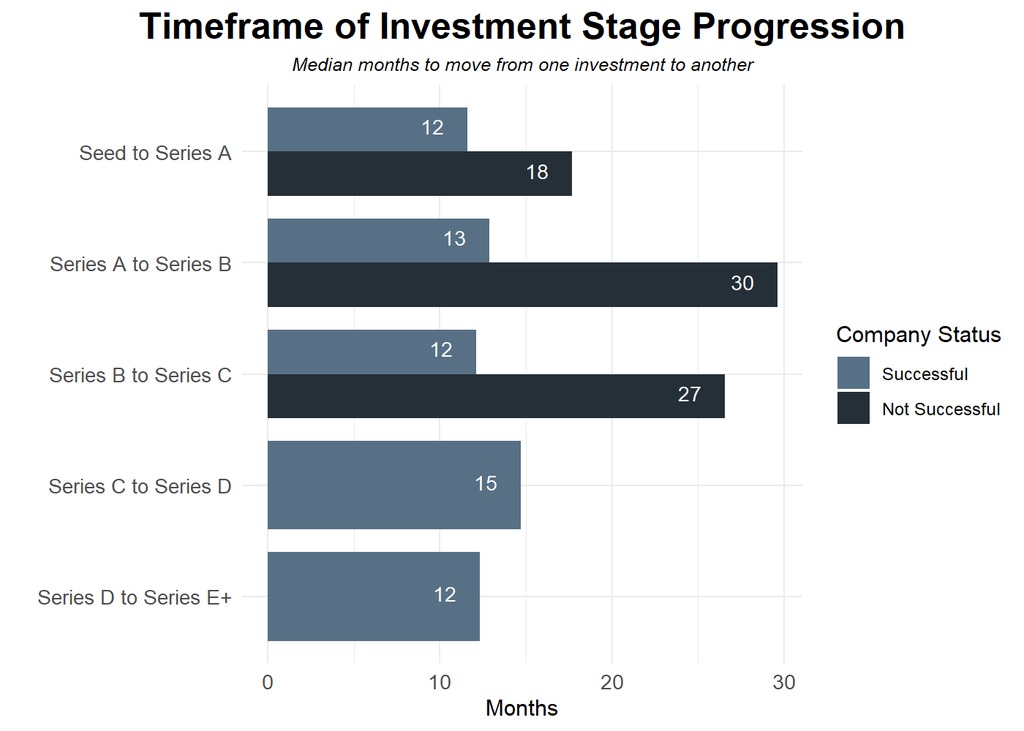

Figure 9. Time it takes companies to move from one funding round to another

The timeframe a company takes to move forward to the next investment stages is another key element that investors consider. The graph shows the median duration a company typically takes to progress from an early to a later investment stage. A few interesting observations are:  
- Successful companies **usually secure a Series A investment within a year.** In contrast, **unsuccessful companies can take up to a year and a half.**  
- The shift to a Series B is challenging for all companies, but **successful ones manage it in 13 months**, while **unsuccessful ones can take as long as 30 months — over twice as long.**  
- This trend continues into the transition to **Series C**, where **unsuccessful companies require 27 months.**  
- Unsuccessful companies generally **fail to reach a Series D or further rounds.**  
- Successful companies **maintain a steady influx of investments, with an average interval of a year between rounds.**

# Part 2: Fitting a logistic regression model

Now, based on the previous analysis. I’m developing a logistic regression model.

```r
set.seed(123)
# Select all numeric variables
numeric_companies <- raw_data_vc %>%
  # Mutate success as a number, where 1 = Success and 0 = Not Successful
  # Mutate team as a number, where 1 = Co-Founder Team and 0 = Solo Founder
  # Mutate foreign funding as a number, where 1 = Has received foreign funding and 0 = Has not received foreign funding
  mutate(success= as.numeric(if_else(success == "Successful",1,0)),
         team = as.numeric(if_else(team == "Co-Founder Team",1,0)),
         foreign_funding_all = as.numeric(if_else(foreign_funding_all== "Yes",1,0))) %>%
  ungroup() %>%
  select_if(is.numeric)

# Mutate variables as factors so the model captures the levels correctly
numeric_companies$success <- as.factor(numeric_companies$success)
numeric_companies$team <- as.factor(numeric_companies$team)
numeric_companies$foreign_funding_all <- as.factor(numeric_companies$foreign_funding_all)

# Split training and testing datasets respectively
datos_split = initial_split(numeric_companies, prop = 0.7,strata = success)
datos_train = training(datos_split)
datos_test  = testing(datos_split)

# Fit the logistic regression model where the variable to predict is success of a company
logit <- glm(success ~ ., data = datos_train %>% dplyr::select(c(-avg_months_between_rounds,
                                                          -funding_usd,
                                                          -median_funding)), family = "binomial")
```

**Logistic Regression Summary**

|  | *Dependent variable:* |
| --- | --- |
|  | company_success |
| `Received Foreign Funding (1=Yes)`1 | -0.15 |
|  | (0.61) |
| `Total Employees` | 0.01** |
|  | (0.005) |
| `Team Composition (1= Co-Founder Team)`1 | 1.59** |
|  | (0.78) |
| `Months to achieve first round` | -0.01 |
|  | (0.01) |
| `Months between first and last round` | -0.01 |
|  | (0.02) |
| `Total Raised` | 0.0000*** |
|  | (0.00) |
| `Total funding rounds` | 0.44 |
|  | (0.27) |
| `Total Investors` | 0.29** |
|  | (0.15) |
| Constant | -3.55*** |
|  | (1.02) |
| Observations | 165 |
| Log Likelihood | -38.57 |
| Akaike Inf. Crit. | 95.14 |
| *Note:* | p<0.1; p<0.05; p<0.01 |

- The Variance Inflation Factor (VIF) for the regression is relatively low, particularly when we consider a benchmark of 5 as high.
- This suggests that there’s no substantial multicollinearity among the variables.

  VIF Values for each regressor

  |  | VIF Value |
  | --- | --- |
  | `Received Foreign Funding (1=Yes)` | 1.112138 |
  | `Total Employees` | 1.110112 |
  | `Team Composition (1= Co-Founder Team)` | 1.143243 |
  | `Months to achieve first round` | 1.170025 |
  | `Months between first and last round` | 2.437043 |
  | `Total Raised` | 1.106142 |
  | `Total funding rounds` | 2.558997 |
  | `Total Investors` | 1.042223 |

### Confusion Matrices

- Comparing the model’s predictions on the training and testing datasets, there are minimal false positives and false negatives.
- This indicates that the model is performing effectively on both datasets.

Confusion Matrix for Testing Dataset

|  | Actual Failure | Actual Success |
| --- | --- | --- |
| Predicted Failure | 10 | 2 |
| Predicted Success | 4 | 57 |

Confusion Matrix for Training Dataset

|  | Actual Failure | Actual Success |
| --- | --- | --- |
| Predicted Failure | 27 | 11 |
| Predicted Success | 5 | 122 |

### Model Performance Metrics

Model performance metrics for testing dataset

[output not shown]

Model performance metrics for training dataset

[output not shown]

### Area under the curve.

- To maximize the precision of predictions, I assessed the Area Under the Curve (AUC) for the model, in addition to conventional accuracy and F1 Score.
- The AUC values are impressively high, nearing 100%, and show negligible variation between the testing and training datasets.
- These results underscore the effectiveness of the logistic regression model, emphasizing its enhanced discrimination capability and predictive accuracy.

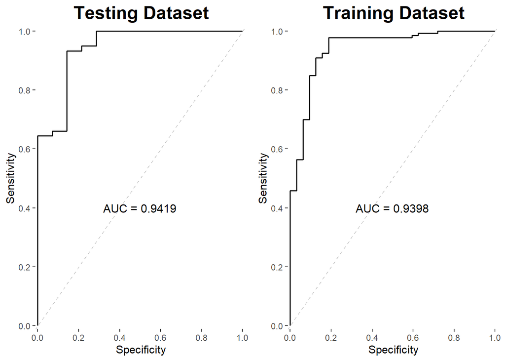

### Predictions on real world data.

The following data frames contain real data from two companies.  
Due to confidentiality obligations, I won’t disclose the names of these companies. However, this data is crucial for making predictions about their success.

Company A Data

| Total Employees | Received Foreign Funding (1=Yes) | Team Composition (1= Co-Founder Team) | Months to achieve first round | Months between first and last round | Total Raised | Total funding rounds | Total Investors |
| --- | --- | --- | --- | --- | --- | --- | --- |
| 109 | 1 | 1 | 12 | 16 | 17310000 | 3 | 4 |

Company B Data

| Total Employees | Received Foreign Funding (0= No) | Team Composition (0= Solo Founder) | Months to achieve first round | Months between first and last round | Total Raised | Total funding rounds | Total Investors |
| --- | --- | --- | --- | --- | --- | --- | --- |
| 26 | 1 | 0 | 24 | 36 | 10000000 | 2 | 2 |

## Based on this data, the probability of success for these companies is:

| Chance of Company A being successful |
| --- |
| 87% |

| Chance of Company B being successful |
| --- |
| 9% |

As we can see, company A is closer to getting a 20+ million dollars funding round. While company B is close to being acquired or closed with just a 9% chance of being successful.

### Limitations:

While the model has demonstrated robust performance, it does have some limitations.  
One of the primary constraints is that the model relies heavily on the structure of the founding team, particularly whether the company has a solo founder or a team of co-founders. This may lead to some bias in the model’s predictions, as it places significant weight on this variable, potentially overlooking other critical factors.  
Furthermore, the model is designed to analyze a specific set of variables, which may not encompass all factors that could influence a company’s success. Business outcomes can be influenced by a myriad of external factors, such as changes in market trends, economic fluctuations, and regulatory changes, which the model may not account for.  
It is important to note that the model is based on historical data, which means its predictions are inherently rooted in past trends. While these trends can often provide a reliable guide, they do not guarantee future outcomes, as the business landscape is continually evolving.  
Therefore, while the model provides valuable insights, it should not be the sole tool used in decision-making. It’s essential to use these predictions alongside other business analysis tools, expert opinion, and consideration of broader market and industry trends to make well-rounded decisions.